# Simulation

05/26/2022

# Objective

This file provides the code to set up the simulation for the paper titled Paul, S., Nath, S., Warren, K., (2022). Causal Network Influence with Latent Homophily and Measurement Error: An Application to Therapeutic Community, [Preprint at arXiv: 2203.14223](https://arxiv.org/pdf/2203.14223.pdf)

The simulation code is divided into the following components

# Experiment Set-up

1. We generate the networks from a Stochastic Block Model (SBM) with increasing number of nodes $n=\{50, 75, 100, 125, 150, 200, 250, 300, 400, 500, 600\}$
2. Set up the experiment for recovery of $\rho$, $\gamma$, $\sigma^2$, standard errors.
3. The number of communities are set at four and the dimension of the latent homophily is set at two.
4. We set $\beta_{0}=[1,2],\rho_{0}=0.4,\sigma_{0}=0.8,\gamma_{0}=[0.2,-0.3]$.
5. Matrix of probabilities $P$ is generated as $P=UU^T$, where the matrix $U_{n \times 2}$ is generated such that it has only 4 unique rows.
   - The resulting block matrix of probabilities is

$$\begin{pmatrix}
0.53 & 0.19 & 0.18 & 0.45\\
0.19 & 0.37 & 0.14 & 0.35 \\
0.18 & 0.14 & 0.08 & 0.20 \\
0.45 & 0.35 & 0.20 & 0.50 \\
\end{pmatrix}$$

```r
#simulation not run (as eval=FALSE)
#if want to run the simulation, remove eval=FALSE above

## varying the number of nodes
nodes = c(50,75,100,125,150,200,250,300,400,500,600)

## number of communities fixed at 4, number of dimensions of the latent homophily vectors is 2.
comms = 4
d =2
beta0 =c(1,2)
rho0 =0.4
sigma0 =0.8
scale=1

gamma0 = c(0.2,-0.3)

estbeta<-list()
sebeta<-list()
testbeta<-list()
estsigma<-list()

for (m in 1:length(nodes)){

## generate community assignment matrix
meanprop<-rmultinom(nodes[m],1,rep(1/comms,comms))

U = matrix(c(0.7,0.1,0.2,0.5,0.2,0.6,0.2,0.5),4,2)
Bmat = scale*U%*%t(U)

Ubig = t(meanprop)%*%U

Z= matrix(rnorm(2*nodes[m],0,0.5),nodes[m],2)
Z[,1] = Z[,1]+ 2*Ubig[,1] + Ubig[,2]
Z[,2] = Z[,2] + 0.8*Ubig[,1]+ Ubig[,2]



### Probability matrix according to RDPG SBM
pmat<-t(meanprop)%*%Bmat%*%meanprop



estbeta[[m]] = matrix(NA,9,200)
sebeta[[m]] = matrix(NA,9,200)
testbeta[[m]] = matrix(NA,9,200)
estsigma[[m]] = matrix(NA,3,200)




for( i in 1:200){
  X= matrix(0,nodes[m],nodes[m])
  for(k in 1:(nodes[m]-1))
  {
    for(j in (k+1):nodes[m])
    {
      X[k,j]<-rbinom(1,1,pmat[k,j])
      X[j,k]<-X[k,j]
    }
  }
  D = rowSums(X)
  D[D<1]=1
  L = X/D
  invX = solve(diag(nodes[m]) - rho0*L)

  Y = mvrnorm(n=1,mu = c(invX%*%((Ubig%*%beta0) + (Z%*%gamma0))),Sigma = invX%*%invX*sigma0^2)




  estclassic = sarMLclassicZ(Y,L,X,Z)
  estbeta[[m]][1,i] = estclassic$influence
  estbeta[[m]][2,i] = estclassic$betacovariate[1]
  estbeta[[m]][3,i] = estclassic$betacovariate[2]

  sebeta[[m]][1,i] = estclassic$SEinfluence
  sebeta[[m]][2,i] = estclassic$SEbetacovariate[1]
  sebeta[[m]][3,i] = estclassic$SEbetacovariate[2]

  testbeta[[m]][1,i] = ifelse(estclassic$pvaluerho<0.05,1,0)
  testbeta[[m]][2,i] = ifelse(estclassic$pvaluecovariate[1]<0.05,1,0)
  testbeta[[m]][3,i] = ifelse(estclassic$pvaluecovariate[2]<0.05,1,0)

  estsigma[[m]][1,i] =  estclassic$sigmasqhat

  ests = sarMLZ(Y,L,X,Z,d=2)
  estbeta[[m]][4,i] = ests$influence
  estbeta[[m]][5,i] = ests$betacovariate[1]
  estbeta[[m]][6,i] = ests$betacovariate[2]

  sebeta[[m]][4,i] = ests$SEinfluence
  sebeta[[m]][5,i] = ests$SEbetacovariate[1]
  sebeta[[m]][6,i] = ests$SEbetacovariate[2]

  testbeta[[m]][4,i] = ifelse(ests$pvaluerho<0.05,1,0)
  testbeta[[m]][5,i] = ifelse(ests$pvaluecovariate[1]<0.05,1,0)
  testbeta[[m]][6,i] = ifelse(ests$pvaluecovariate[2]<0.05,1,0)

  estsigma[[m]][2,i] =  ests$sigmasqhat

  estmod = sarMLZc(Y,L,X,Z,d=2,comms=4)
  estbeta[[m]][7,i] = estmod$influence
  estbeta[[m]][8,i] = estmod$betacovariate[1]
  estbeta[[m]][9,i] = estmod$betacovariate[2]

  sebeta[[m]][7,i] = estmod$SEinfluence
  sebeta[[m]][8,i] = estmod$SEbetacovariate[1]
  sebeta[[m]][9,i] = estmod$SEbetacovariate[2]

  testbeta[[m]][7,i] = ifelse(estmod$pvaluerho<0.05,1,0)
  testbeta[[m]][8,i] = ifelse(estmod$pvaluecovariate[1]<0.05,1,0)
  testbeta[[m]][9,i] = ifelse(estmod$pvaluecovariate[2]<0.05,1,0)

  estsigma[[m]][3,i] =  estmod$sigmasqhat


}
}
```

# Compare the performance of estimators

In this section, we compare estimates of the network influence parameter $\rho$ from the naive model (model with no latent factors), the model with latent factors but no bias correction, and the model with latent factors and bias correction.

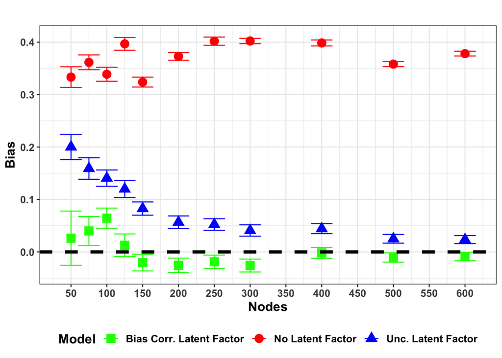

```r
load("simuldatamain1.RData")
simuldatamain=simuldatamain1

theta= c(0.4)
nodes= simuldatamain$nodes
estbeta= simuldatamain$estbeta
sebeta=simuldatamain$sebeta


biasg1 = matrix(unlist(lapply(estbeta,function(x){
  return(c(mean(x[1,]-theta[1]),mean(x[4,]-theta[1]),mean(x[7,]-theta[1])))
})),3,length(nodes))


sdg1 = matrix(unlist(lapply(estbeta,function(x){
  return(c(sd(x[1,]-theta[1]),sd(x[4,]-theta[1]),sd(x[7,]-theta[1])))
})),3,length(nodes))


d1=biasg1[1,]
d2=rep("No Latent Factor",length(d1))

e1=biasg1[2,]
e2=rep("Unc. Latent Factor",length(d1))

f1=biasg1[3,]
f2=rep("Bias Corr. Latent Factor",length(d1))

data1=data.frame(d1,d2)
colnames(data1)=c("Bias","Model")

data2=data.frame(e1,e2)
colnames(data2)=c("Bias","Model")

data3=data.frame(f1,f2)
colnames(data3)=c("Bias","Model")


data=rbind(data1,data2,data3)

dd1=sdg1[1,]
dd1=data.frame(dd1)
colnames(dd1)=c("se")


dd2=sdg1[2,]
dd2=data.frame(dd2)
colnames(dd2)=c("se")

dd3=sdg1[3,]
dd3=data.frame(dd3)
colnames(dd3)=c("se")

datadse=rbind(dd1,dd2,dd3)

data=cbind(data,datadse)

data$nodes=rep(nodes,3)

datanew=data

datanew$se=datanew$se/sqrt(200)

data$se=data$se/sqrt(200)


datanew %>%
  ggplot( aes(x=nodes, y=Bias, group="", color=Model)) +
  geom_errorbar( aes(x=nodes, ymin=Bias-1.96*se, ymax=Bias+1.96*se), width=30) +
  geom_point(aes(shape=Model, color=Model), size=4) +
  scale_shape_manual(values=c(15, 16, 17))+
  scale_color_manual(values=c('green','red', 'blue'))+
  theme_bw()+
  theme(legend.position = "bottom",text = element_text(size = 13,face="bold")) +
  ggtitle("")+xlab("Nodes")+guides(colour = guide_legend(nrow = 1))+geom_hline(yintercept=0, linetype="dashed", color = "black",, size=1.5)+
  scale_x_continuous(breaks = round(seq(min(datanew$nodes), max(datanew$nodes), by = 50),1))
```

# Simulation for the least squares networked regression

1. We perform a simulation study to check if the bias corrected estimator using the estimated covariance matrix from the spectral embedding of SBM performs better than the uncorrected estimator.
2. Since OLS is used to estimate the model, we simplify the simulation setup by generating $U$ and $Z$ correlated with each other and generating $Y$ as $Y=U\beta + Z\gamma + \epsilon$. We set the dimensions of $U_i$ and $Z_i$ as 3 and 2 respectively.
3. As before the network $A$ is generated from a SBM with $k=3$ communities with $U$ being the latent homophily variable (therefore $U$ has 3 unique rows). Our goal is to correctly identify the parameters $\gamma_1, \gamma_2$.

```r
#### Simulation for the least squares network regression case

nodes = c(50,100,150,200,300,400,500,600,700,800)
comms = 3
d =3
d2 =2
beta =c(1,2,0.5)
theta = c(0.3,-0.4)



estbeta<-list()
serbeta<-list()

for (m in 1:length(nodes)){
meanprop<-rmultinom(nodes[m],1,rep(1/comms,comms))

Bmat=matrix(c(0.7,0.2,0.3,0.2,0.8,0.25,0.3,0.25,0.75),3,3)
spectra= eigen(Bmat)
U= spectra$vectors[,1:d]%*%diag(sqrt(spectra$values[1:d]))


Ubig = t(meanprop)%*%U

Z= matrix(rnorm(2*nodes[m],0,0.5),nodes[m],2)
Z[,1] = Z[,1]+ 2*Ubig[,1] + Ubig[,2]
Z[,2] = Z[,2] + Ubig[,1]+ Ubig[,3]


pmat<-t(meanprop)%*%Bmat%*%meanprop

estbeta[[m]] = matrix(NA,6,200)
sebeta[[m]] = matrix(NA,6,200)



for ( i in 1:200){
X= matrix(0,nodes[m],nodes[m])
for(k in 1:(nodes[m]-1))
  {
    for(j in (k+1):nodes[m])
    {
      X[k,j]<-rbinom(1,1,pmat[k,j])
      X[j,k]<-X[k,j]
      }
  }

Y = c(Ubig%*%beta) + c(Z%*%theta) + rnorm(nodes[m],0,1)



spectra<-eigen(X)
Uhat<-spectra$vectors[,1:d]%*%diag(sqrt(spectra$values[1:d]))
regdata = data.frame(Y=Y,Uhat=Uhat,Z=Z)
# incorrect
betanull = lm(Y~0+Z,data=regdata)

# uncorrected
betalm = lm(Y~0+.,data=regdata)

# bias corrected
betacor = lfreg(Y,X,Z,d=3,comms=3)

estbeta[[m]][1:2,i] = betanull$coefficients[1:2]


estbeta[[m]][3:4,i] = betalm$coefficients[4:5]


estbeta[[m]][5:6,i] = betacor$betac[4:5]


sebeta[[m]][1:2,i] = summary(betanull)$coefficients[1:2,2]

sebeta[[m]][3:4,i] = summary(betalm)$coefficients[4:5,2]

sebeta[[m]][5:6,i] = betacor$sebetac[4:5]



}
}
```

## Simulation Output

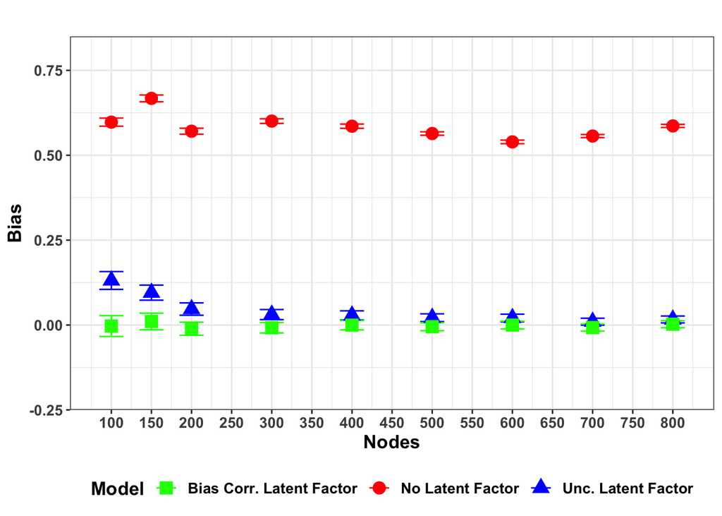

```r
load("simuldata.RData")

theta= c(0.3, -0.4)
nodes= simuldata$nodes
estbeta= simuldata$estbeta
sebeta=simuldata$sebeta

biasg1 = matrix(unlist(lapply(estbeta,function(x){
  return(c(mean(x[1,]-theta[1]),mean(x[3,]-theta[1]),mean(x[5,]-theta[1])))
})),3,length(nodes))

biasg2 = matrix(unlist(lapply(estbeta,function(x){
  return(c(mean(x[2,]-theta[2]),mean(x[4,]-theta[2]),mean(x[6,]-theta[2])))
})),3,length(nodes))

sdg1 = matrix(unlist(lapply(estbeta,function(x){
  return(c(sd(x[1,]-theta[1]),sd(x[3,]-theta[1]),sd(x[5,]-theta[1])))
})),3,length(nodes))

sdg2 = matrix(unlist(lapply(estbeta,function(x){
  return(c(sd(x[2,]-theta[2]),sd(x[4,]-theta[2]),sd(x[6,]-theta[2])))
})),3,length(nodes))






d1=biasg1[1,]
d2=rep("No Latent Factor",length(d1))

e1=biasg1[2,]
e2=rep("Unc. Latent Factor",length(d1))

f1=biasg1[3,]
f2=rep("Bias Corr. Latent Factor",length(d1))

data1=data.frame(d1,d2)
colnames(data1)=c("Bias","Model")

data2=data.frame(e1,e2)
colnames(data2)=c("Bias","Model")

data3=data.frame(f1,f2)
colnames(data3)=c("Bias","Model")


data=rbind(data1,data2,data3)

dd1=sdg1[1,]
dd1=data.frame(dd1)
colnames(dd1)=c("se")


dd2=sdg1[2,]
dd2=data.frame(dd2)
colnames(dd2)=c("se")

dd3=sdg1[3,]
dd3=data.frame(dd3)
colnames(dd3)=c("se")

datadse=rbind(dd1,dd2,dd3)

data=cbind(data,datadse)

data$nodes=rep(nodes,3)

datanew=subset(data,data$nodes!=50)

datanew$se=datanew$se/sqrt(200)

data$se=data$se/sqrt(200)



datanew %>%
  ggplot( aes(x=nodes, y=Bias, group="", color=Model)) +
  geom_errorbar( aes(x=nodes, ymin=Bias-1.96*se, ymax=Bias+1.96*se), width=30) +
  geom_point(aes(shape=Model, color=Model), size=4) +
  scale_shape_manual(values=c(15, 16, 17))+
  scale_color_manual(values=c('green','red', 'blue'))+
  theme_bw()+
  theme(legend.position = "bottom",text = element_text(size = 13,face="bold")) +
  ggtitle("")+xlab("Nodes")+ylim(-0.2,0.8)+guides(colour = guide_legend(nrow = 1))+
  scale_x_continuous(breaks = round(seq(min(datanew$nodes), max(datanew$nodes), by = 50),1))
```

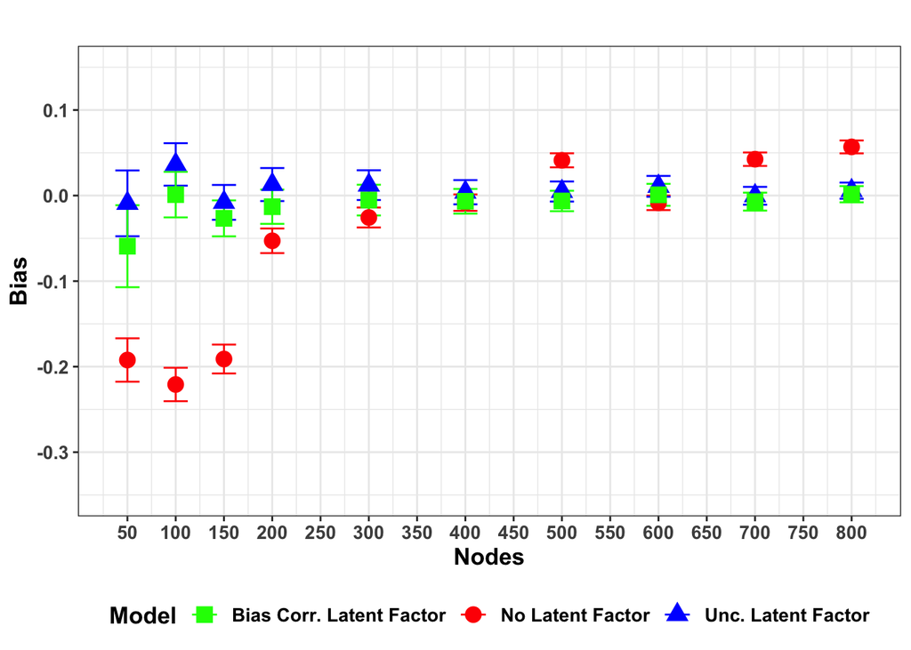

```r
d1=biasg2[1,]
d2=rep("No Latent Factor",length(d1))

e1=biasg2[2,]
e2=rep("Unc. Latent Factor",length(d1))

f1=biasg2[3,]
f2=rep("Bias Corr. Latent Factor",length(d1))

data1=data.frame(d1,d2)
colnames(data1)=c("Bias","Model")

data2=data.frame(e1,e2)
colnames(data2)=c("Bias","Model")

data3=data.frame(f1,f2)
colnames(data3)=c("Bias","Model")


data=rbind(data1,data2,data3)

dd1=sdg2[1,]
dd1=data.frame(dd1)
colnames(dd1)=c("se")


dd2=sdg2[2,]
dd2=data.frame(dd2)
colnames(dd2)=c("se")

dd3=sdg2[3,]
dd3=data.frame(dd3)
colnames(dd3)=c("se")

datadse=rbind(dd1,dd2,dd3)

data=cbind(data,datadse)

data$nodes=rep(nodes,3)

datanew=data

datanew$se=datanew$se/sqrt(200)

data$se=data$se/sqrt(200)



datanew %>%
  ggplot( aes(x=nodes, y=Bias, group="", color=Model)) +
  geom_errorbar( aes(x=nodes, ymin=Bias-1.96*se, ymax=Bias+1.96*se), width=25) +
  geom_point(aes(shape=Model, color=Model), size=4) +
  scale_shape_manual(values=c(15, 16, 17))+
  scale_color_manual(values=c('green','red', 'blue'))+
  theme_bw()+
  theme(legend.position = "bottom",text = element_text(size = 13,face="bold")) +
  ggtitle("")+xlab("Nodes")+guides(colour = guide_legend(nrow = 1))+
  scale_x_continuous(breaks = round(seq(min(datanew$nodes), max(datanew$nodes), by = 50),1))+
  ylim(-.35,0.15)
```

# Simulation for longitudinal network influence

1. The data generating model is $Y_{t+1} = \alpha Y_t + \rho L Y_t + U \beta + \epsilon_{t+1}$, where $\epsilon_{t}\sim N(0,1)$
2. We use two time periods. For the frist period $Y_t = U \beta + \epsilon_t$. Then $Y_{t+1}$ is generated as above.
3. The primary parameter of interest is the influence parameter rho.

```r
nodes = c(50,100,150,200,250,300,350,400,450,500,600,700,800)
comms = 4
d =2
d2 =2
beta =c(1,2)
rho=0.3

estbeta<-list()
sebeta<-list()

for (m in 1:length(nodes)){
  meanprop<-rmultinom(nodes[m],1,rep(1/comms,comms))

  U = matrix(c(0.7,0.1,0.2,0.5,0.2,0.6,0.2,0.5),4,2)
  #spectra= eigen(Bmat)
  #U= spectra$vectors[,1:d]%*%diag(sqrt(spectra$values[1:d]))
  Bmat = U%*%t(U)

  Ubig = t(meanprop)%*%U


  pmat<-t(meanprop)%*%Bmat%*%meanprop

  estbeta[[m]] = matrix(NA,3,200)
  sebeta[[m]] = matrix(NA,3,200)



  for ( i in 1:200){
    X= matrix(0,nodes[m],nodes[m])
    for(k in 1:(nodes[m]-1))
    {
      for(j in (k+1):nodes[m])
      {
        X[k,j]<-rbinom(1,1,pmat[k,j])
        X[j,k]<-X[k,j]
      }
    }

    D = rowSums(X)
    D[D<1]=1
    L = X/D

    ## running it for 2 time periods

    Yt =  Ubig%*%beta + rnorm(nodes[m],0,1)
    Yt1 =  Ubig%*%beta + rho*L%*%Yt+ 0.6*Yt + rnorm(nodes[m],0,1)

    ## Z contains two columns, the first one is the network influence
    Z=cbind(L%*%Yt,Yt)

    spectra<-eigen(X)
    Uhat<-spectra$vectors[,1:d]%*%diag(sqrt(spectra$values[1:d]))
    regdata = data.frame(Y=Yt1,Uhat=Uhat,Z=Z)

    # no latent factor
    betanull = lm(Y~0+Z,data=regdata)
    estbeta[[m]][1,i] = betanull$coefficients[1]

    # latent factor but uncorrected
    betalm = lm(Y~0+.,data=regdata)
    estbeta[[m]][2,i] = betalm$coefficients[d+1]

    # bias corrected latent factor
    betacor = lfreg(Yt1,X,Z,d=2,comms=4)
    estbeta[[m]][3,i] = betacor$betac[d+1]




    sebeta[[m]][1,i] = summary(betanull)$coefficients[1,2]

    sebeta[[m]][2,i] = summary(betalm)$coefficients[d+1,2]

    sebeta[[m]][3,i] = betacor$sebetac[d+1]



  }
}
```

## Simulation Output

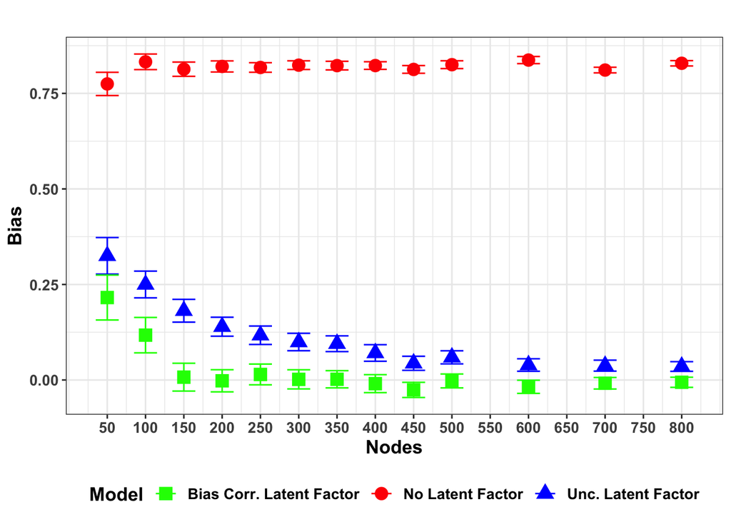

```r
load("simuldatalong.RData")

#nodes= simuldata$nodes
#estbeta= simuldata$estbeta
#sebeta=simuldata$sebeta
theta=0.3

biasg1 = matrix(unlist(lapply(estbeta,function(x){
  return(c(mean(x[1,]-theta[1]),mean(x[2,]-theta[1]),mean(x[3,]-theta[1])))
})),3,length(nodes))



sdg1 = matrix(unlist(lapply(estbeta,function(x){
  return(c(sd(x[1,]-theta[1]),sd(x[2,]-theta[1]),sd(x[3,]-theta[1])))
})),3,length(nodes))



d1=biasg1[1,]
d2=rep("No Latent Factor",length(d1))

e1=biasg1[2,]
e2=rep("Unc. Latent Factor",length(d1))

f1=biasg1[3,]
f2=rep("Bias Corr. Latent Factor",length(d1))

data1=data.frame(d1,d2)
colnames(data1)=c("Bias","Model")

data2=data.frame(e1,e2)
colnames(data2)=c("Bias","Model")

data3=data.frame(f1,f2)
colnames(data3)=c("Bias","Model")


data=rbind(data1,data2,data3)

dd1=sdg1[1,]
dd1=data.frame(dd1)
colnames(dd1)=c("se")


dd2=sdg1[2,]
dd2=data.frame(dd2)
colnames(dd2)=c("se")

dd3=sdg1[3,]
dd3=data.frame(dd3)
colnames(dd3)=c("se")

datadse=rbind(dd1,dd2,dd3)

data=cbind(data,datadse)

data$nodes=rep(nodes,3)

datanew=data

datanew$se=datanew$se/sqrt(200)

data$se=data$se/sqrt(200)



datanew %>%
  ggplot( aes(x=nodes, y=Bias, group="", color=Model)) +
  geom_errorbar( aes(x=nodes, ymin=Bias-1.96*se, ymax=Bias+1.96*se), width=30) +
  geom_point(aes(shape=Model, color=Model), size=4) +
  scale_shape_manual(values=c(15, 16, 17))+
  scale_color_manual(values=c('green','red', 'blue'))+
  theme_bw()+
  theme(legend.position = "bottom",text = element_text(size = 13,face="bold")) +
  ggtitle("")+xlab("Nodes")+ylab("Bias")+guides(colour = guide_legend(nrow = 1))+
  scale_x_continuous(breaks = round(seq(min(datanew$nodes), max(datanew$nodes), by = 50),1))
```